# Modeling and prediction for movies

Valeriy Kondruk

## Setup

### Load packages

```r
library(ggplot2)
library(dplyr)
library(statsr)
library(GGally)
```

### Load data

```r
load("movies.Rdata")
```

## Part 1: Data

We have acquired data about how much audiences and critics like movies as well as numerous other variables about the movies. This dataset includes information from Rotten Tomatoes and IMDb for a random sample of movies.

We’re interested in learning what attributes make a movie popular.

The data set is comprised of 651 randomly sampled movies produced and released before 2016, and scored on both Rotten Tomatoes and IMDb.

We deal with a retrospective observational study with random sampling and with no random assignment here. Which means that we cannot make causal conclusions based on this data. However, we can use this data for making correlation statements, and the results of our findings can be generalized to the whole population of movies released before 2016 and scored on both Rotten Tomatoes and IMDb.

## Part 2: Research question

### Without watching a movie, can we say wether the audience love it?

Obviously, the popularity of a movie is mainly based on its content and the art value it offers. Those two factors are very hard if not impossible to calculate, though. However, there are certain characteristics of a movie that we can calculate and classify comparatively easy. Among others, those are genre, duration, and a cast quality. Using those and other variables from the data frame, we’ll try creating a prediction model for a movie papularity among the audience.

## Part 3: Exploratory data analysis

We start our analysis with a high level overview of the data frame provided. The table below shows the number of movies of three major types (Documentary, Feature Film, and TV Movie) in the data set, the time range of theatre releases (`thtr_rel_year`), as well as the median audience rating on both IMDB (`imdb_rating`) and Rotten Tomatoes (`audience_score`). We choose median instead of mean for the audience rating as we suspect the rating distributions are skewed and median is a more robust statistics for skewed distributions.

```r
movies %>%
  group_by(title_type) %>%
  summarise(n(), min(thtr_rel_year), max(thtr_rel_year), median(imdb_rating), median(audience_score))
```

```
## # A tibble: 3 x 6
##   title_type `n()` `min(thtr_rel_y… `max(thtr_rel_y… `median(imdb_ra…
##   <fct>      <int>            <dbl>            <dbl>            <dbl>
## 1 Documenta…    55             1970             2012              7.7
## 2 Feature F…   591             1972             2014              6.5
## 3 TV Movie       5             1993             2012              7.3
## # … with 1 more variable: `median(audience_score)` <dbl>
```

*Table 1. Movies statistics grouped by the tytle type*

We can see the majority of movies in the data set belongs to the ‘Feature Film’ group. 55 movies are Documentaries and only 5 are TV Movies.

It’s expected that the popularity of movies in these three major groups would depend on very different factors. This partially confirmed by the significant difference between median rating of Featured Films and two other groups. Thus, we decided to deal only with the most populous group of movies in this data set, Featured Films. We then create a subset (*ff* for Feature Film) of the data frame and use it from now:

```r
ff <- movies %>%
  filter(title_type == 'Feature Film')
```

Let’s take a look at the data summary now (we exclude some variables from the summary to make the report shorter):

```r
summary(ff[3:24])
```

```
##                 genre        runtime       mpaa_rating
##  Drama             :301   Min.   : 68.0   G      : 16
##  Comedy            : 85   1st Qu.: 93.0   NC-17  :  2
##  Action & Adventure: 65   Median :104.0   PG     :110
##  Mystery & Suspense: 59   Mean   :106.6   PG-13  :130
##  Horror            : 23   3rd Qu.:116.0   R      :317
##  Other             : 15   Max.   :202.0   Unrated: 16
##  (Other)           : 43
##                               studio    thtr_rel_year  thtr_rel_month
##  Paramount Pictures              : 37   Min.   :1972   Min.   : 1.000
##  Warner Bros. Pictures           : 29   1st Qu.:1990   1st Qu.: 4.000
##  Sony Pictures Home Entertainment: 26   Median :1999   Median : 7.000
##  Universal Pictures              : 23   Mean   :1997   Mean   : 6.783
##  Warner Home Video               : 19   3rd Qu.:2006   3rd Qu.:10.000
##  (Other)                         :451   Max.   :2014   Max.   :12.000
##  NA's                            :  6
##   thtr_rel_day    dvd_rel_year  dvd_rel_month     dvd_rel_day
##  Min.   : 1.00   Min.   :1991   Min.   : 1.000   Min.   : 1.00
##  1st Qu.: 7.00   1st Qu.:2001   1st Qu.: 3.000   1st Qu.: 7.00
##  Median :15.00   Median :2003   Median : 6.000   Median :15.00
##  Mean   :14.48   Mean   :2004   Mean   : 6.304   Mean   :15.06
##  3rd Qu.:21.50   3rd Qu.:2007   3rd Qu.: 9.000   3rd Qu.:23.00
##  Max.   :31.00   Max.   :2015   Max.   :12.000   Max.   :31.00
##                  NA's   :6      NA's   :6        NA's   :6
##   imdb_rating    imdb_num_votes           critics_rating critics_score
##  Min.   :1.900   Min.   :   390   Certified Fresh:116    Min.   :  1.00
##  1st Qu.:5.850   1st Qu.:  6276   Fresh          :172    1st Qu.: 31.00
##  Median :6.500   Median : 17934   Rotten         :303    Median : 57.00
##  Mean   :6.387   Mean   : 62861                          Mean   : 54.78
##  3rd Qu.:7.100   3rd Qu.: 66112                          3rd Qu.: 79.00
##  Max.   :9.000   Max.   :893008                          Max.   :100.00
##
##  audience_rating audience_score  best_pic_nom best_pic_win best_actor_win
##  Spilled:273     Min.   :11.00   no :569      no :584      no :500
##  Upright:318     1st Qu.:44.50   yes: 22      yes:  7      yes: 91
##                  Median :62.00
##                  Mean   :60.47
##                  3rd Qu.:78.00
##                  Max.   :97.00
##
##  best_actress_win best_dir_win top200_box
##  no :521          no :548      no :576
##  yes: 70          yes: 43      yes: 15
##
##
##
##
##
```

The variables of most interest are related to movies rating: audience rating on IMDB (`imdb_rating`), critics score on Rotten Tomatoes (`critics_score`), and audience score on Rotten Tomatoes (`audience_score`). We can see that median statistics for all three variables are higher than respective mean statistics. This proves our early assumption of the skeweness of the rating distributions. In fact, all three distributions are **left skewed**. This can also be demonstrated with the following histograms:

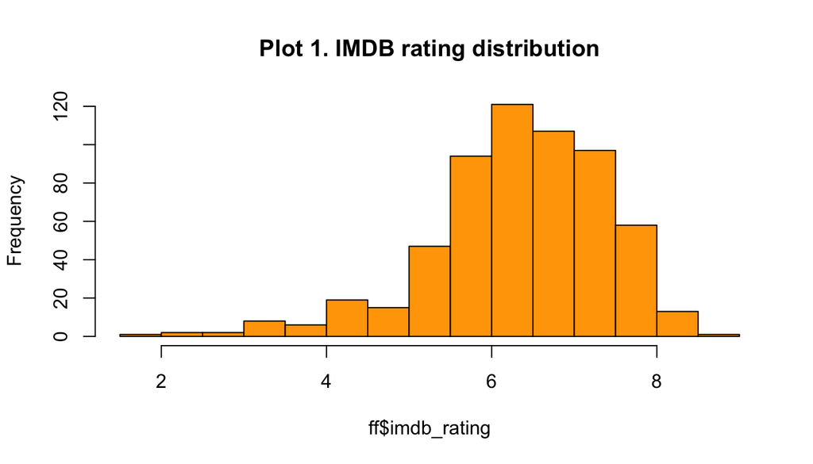

```r
hist(ff$imdb_rating, main = 'Plot 1. IMDB rating distribution', col = 'orange')
```

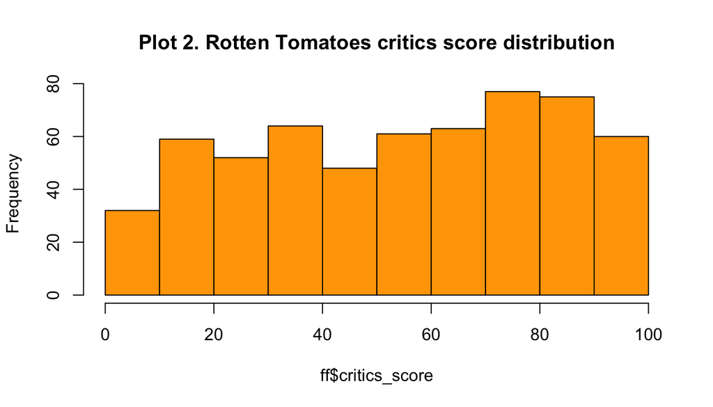

```r
hist(ff$critics_score, main = 'Plot 2. Rotten Tomatoes critics score distribution', col = 'orange')
```

[figure not shown]

```r
hist(ff$audience_score, main = 'Plot 3. Rotten Tomatoes audience score distribution', col = 'orange')
```

Interesting that IMDB rating shows a unimodal left skewed distribution centered around 6.4 (Plot 1) but both scores on Rotten Tomatoes show almost a uniform distribution with a slight left skew and no apparent centers (Plot 2 and 3). This discrepancy could be explained by the larger number of voting users on IMDb so the true population mean is more obvious. But this is questionable as we don’t have data on the number of votes for Rotten Tomatoes scores.

We can also conclude that **IMDB users are less likely to give a low rating to a movie** than Rotten Tomatoes users and critics. Indeed, 75% of movies received a rating of 58.5 (or 5.85 on a scale of 1 to 10) or higher on IMDB, 44.5 or higher from the audience on RT, and only 31 or higher from the critics on RT.

However, the most plausible cause of the diferencies in distributions lies in methods of calculating rating and scores on two platforms:

- IMDb registered users can cast a vote (from 1 to 10) on every released title in the database. Individual votes are then aggregated and summarized as a single IMDb rating, visible on the title’s main page.
- Rotten Tomatoes critics score represents the percentage of professional critic reviews that are positive for a given film.
- Rotten Tomatoes audience score is the percentage of users who have rated the movie positively (a star rating of 3.5 or higher out of 5 stars).

Basically, **the Rotten Tomatoes score only counts positive rates while IMDb rating counts all rates**.

For example, an audience score of 25% on Rotten Tomatoes can be translated to an IMDb rating between 2.5 and 7.5 depending on individual ratings that made up that 25% score on RT. In other words, in the plots above we do not compare apples to apples (or we should say tomatoes to tomatoes).

Let’s take a look at the median statistics for feature films grouped by genre:

```r
ff %>%
  group_by(genre) %>%
  summarise(total = n(), IMDb = median(imdb_rating), RT_critics = median(critics_score), RT_audience = median(audience_score))
```

```
## # A tibble: 11 x 5
##    genre                     total  IMDb RT_critics RT_audience
##    <fct>                     <int> <dbl>      <dbl>       <dbl>
##  1 Action & Adventure           65  6            33        52
##  2 Animation                     9  6.4          48        65
##  3 Art House & International    14  6.5          52        65.5
##  4 Comedy                       85  5.7          36        49
##  5 Documentary                   3  6.9          40        74
##  6 Drama                       301  6.8          67        70
##  7 Horror                       23  5.9          40        43
##  8 Musical & Performing Arts     8  7.25         80        82.5
##  9 Mystery & Suspense           59  6.5          60        54
## 10 Other                        15  7            72        74
## 11 Science Fiction & Fantasy     9  5.9          67        47
```

*Table 2. Feature Films rating and scores medians by genre*

We can see that Drama is the most populous category with more than half movies of the data set and median IMDb rating of 6.80, RT critics score of 67, and RT audience score of 70. The highest median IMDb rating of 7.25 is in Musical & Performing Arts category. This group also has the highest scores of all on RT among both critics and audience. We need to note that only 8 movies fall in this group, so this stats can be quite different for a larger sample. The Comedy group has the lowest median IMDb rating of all, 5.70, second to lowest for RT critics and third to lowest for RT audience.

It’s interesting to see the distribution of movies runtime:

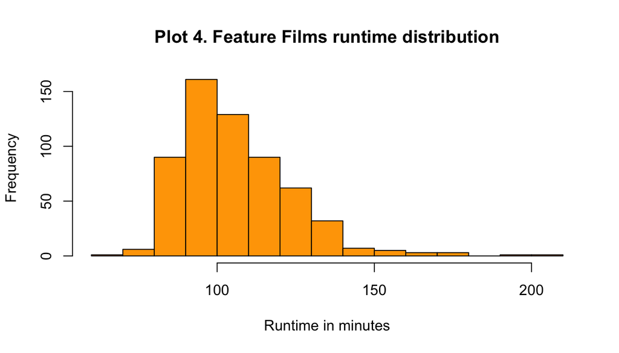

```r
hist(ff$runtime, main = 'Plot 4. Feature Films runtime distribution', xlab = 'Runtime in minutes', col = 'orange')
```

Here we can see a right skewed unimodal distribution centered around 100 minutes with several outliers.

## Part 4: Modeling

The data set contains several variables on movies: title, runtime, date of release, production company, cast, nominations, ratings, and scores. We’d love to predict the popularity of the movie (represented by the IMDb rating, Rotten Tomatoes critics and audience scores) based on a certain combination of the rest of the variables using a multiple linear regression method.

We will start with modelling where response variable is IMDb rating (`imdb_rating`).

### IMDb rating prediction model

Developing a full model as a reference to all future models would be a good first step. The full model includes all potential predictor variables. However, we would omit some of the variables as they are only in data set for informational purposes and do not make any sense to include in a statistical analysis.

Here’s a list of variables we can ommit:

- The information in the `director`, and `actor1` through `actor5` variables was used to determine whether the movie casts a director, an actor or actress who won Oscar.
- Variable like `imdb_url` and `rt_url` obviously cannot be associated with the popularity of a movie, thus should be ommited.
- Wording of a `title` of the movie by itself is meaningless for answering the research question. But we can try using a title length as a predictor.
- We can omit the `title_type` variable as we only work with Feature Film here.
- The actual day of the month of the theatrical (`thtr_rel_day`) or dvd (`dvd_rel_day`) release is also meanengless for predicting movie’s popularity. We can think of some correlation between a month or year and a movie popularity. We suspect it’s going to be low if any, though.
- We should also omit `critics_rating` and `audience_rating` variables as they are basically the derivatives of `critics_score` and `audience_score` variables respectively. So, they are obviously collinear and adding more than one of these variables to the model would not add much value to the model.

The question is **whether we should use Rotten Tomatoes scores in predicting IMDb rating** and vice versa. Technically speaking, a popular movie would rate high on both platforms (it’s not always the case, though). This means that rating on IMDb would have a positive correlation with audience score on RT despite the fact they are calculated differently. We can check if this is the case by calculating a correlation coefficient:

```r
cor(y = ff$imdb_rating, x = ff$audience_score)
```

```
## [1] 0.8487537
```

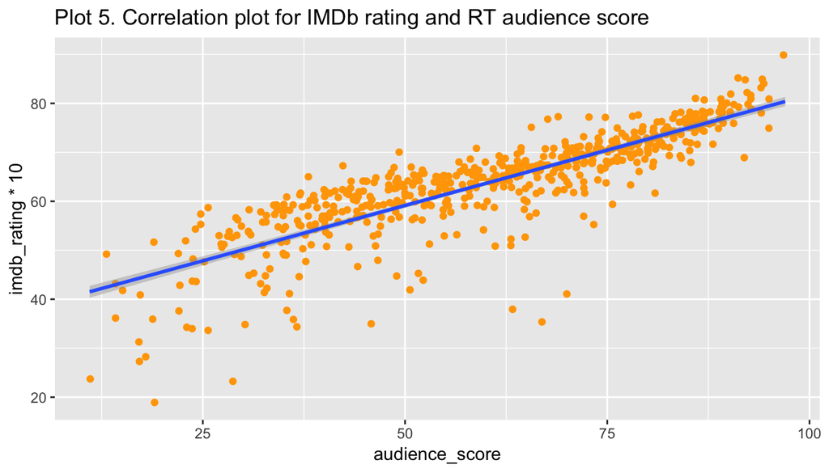

```r
ff %>%
  ggplot(aes(y = imdb_rating*10, x = audience_score)) +
  geom_jitter(col = 'orange') +
  labs(title = 'Plot 5. Correlation plot for IMDb rating and RT audience score') +
  geom_smooth(method = lm)
```

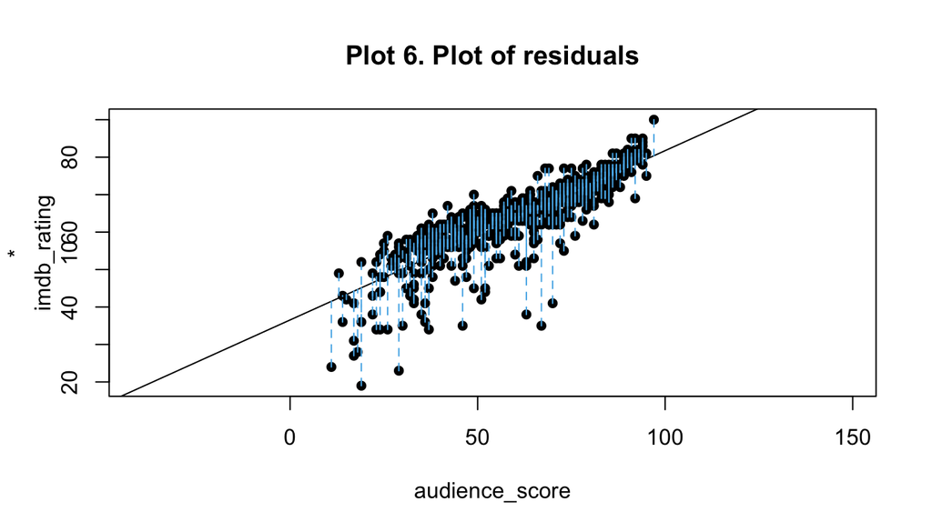

```
## Click two points to make a line.

## Call:
## lm(formula = y ~ x, data = pts)
##
## Coefficients:
## (Intercept)            x
##     36.5493       0.4519
##
## Sum of Squares:  18380.56
```

```
## integer(0)
```

```r
plot_ss(y = imdb_rating*10, x = audience_score, data = ff) +
  title(main = "Plot 6. Plot of residuals")
```

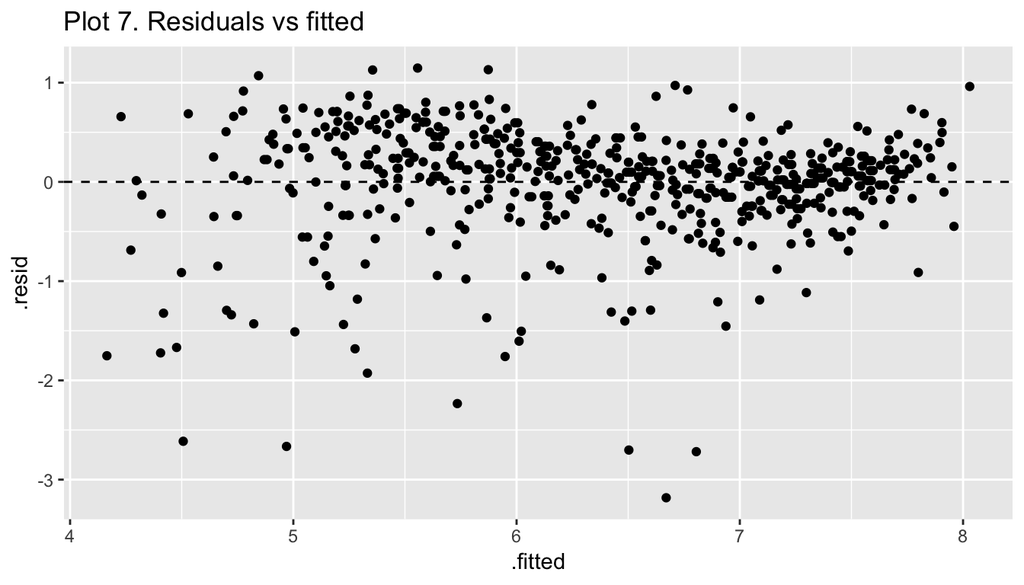

```r
m_obs <- lm(imdb_rating ~ audience_score, data = ff)

ggplot(data = m_obs, aes(x = .fitted, y = .resid)) +
  geom_jitter() +
  geom_hline(yintercept = 0, linetype = "dashed") +
  labs(title = "Plot 7. Residuals vs fitted", xlab = "Fitted values", ylab = "Residuals")
```

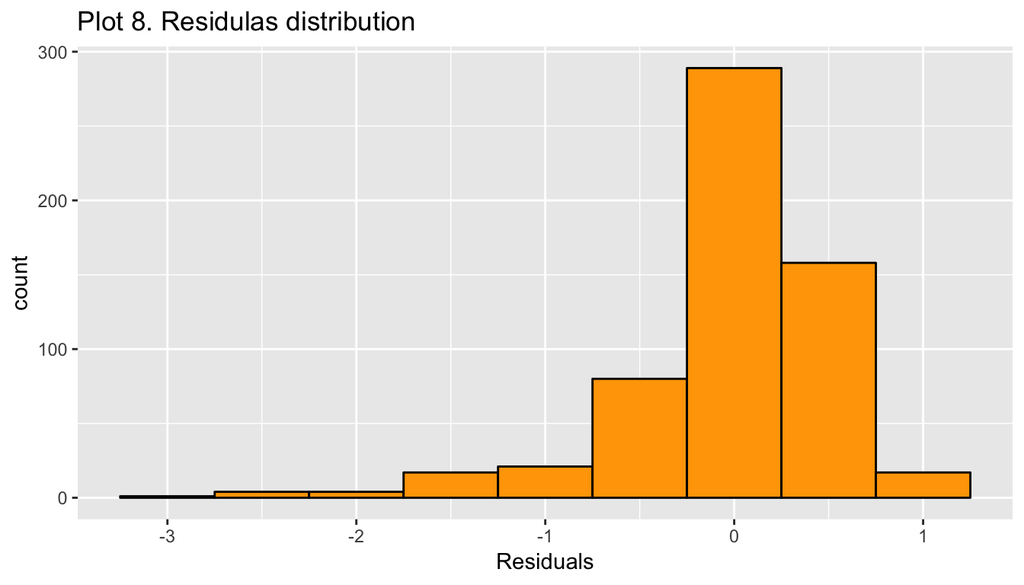

```r
ggplot(data = m_obs, aes(x = .resid)) +
  geom_histogram(binwidth = 0.5, fill = "orange", colour = "black") +
  xlab("Residuals") +
  ggtitle("Plot 8. Residulas distribution")
```

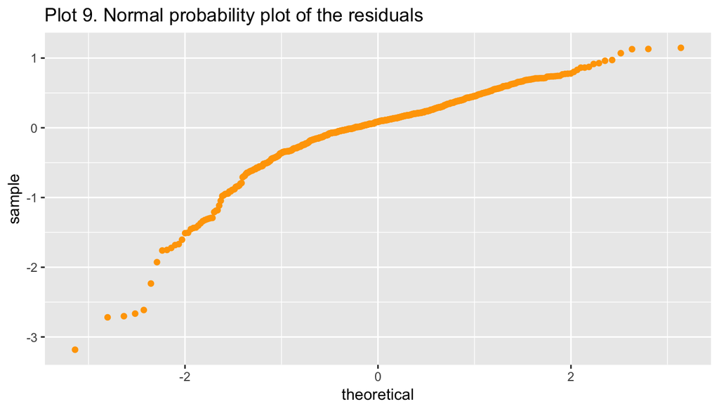

```r
ggplot(data = m_obs, aes(sample = .resid)) +
  stat_qq(col = "orange") +
  ggtitle("Plot 9. Normal probability plot of the residuals")
```

Indeed, we can see that the correlation coefficient is very high (~0.85) and positive. However, the variance doesn’t seem to be constant (little variance for popular movies and larger variance for unpopular movies) for the reason discussed in Part 3. There’s definitely a correlation between these two variables but it’s not linear.

The previous assumption is even more apparent with RT critics score and critics rating variables plotted against IMDb audience rating (Plots 10-13):

[figure not shown]

```r
ff %>%
  ggplot(aes(y = imdb_rating*10, x = critics_score)) +
  geom_jitter(col = 'orange') +
  labs(title = 'Plot 10. Correlation plot for IMDb rating and RT critics score') +
  geom_smooth(method = lm)
```

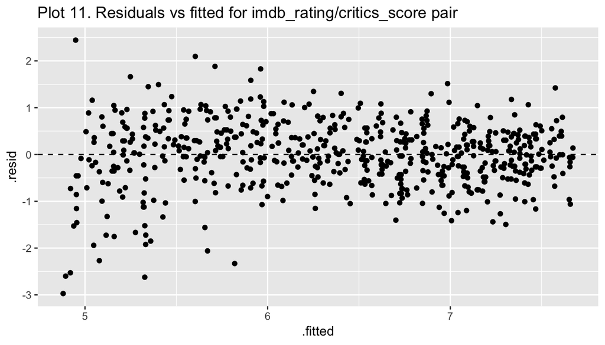

```r
m_obs3 <- lm(imdb_rating ~ critics_score, data = ff)

ggplot(data = m_obs3, aes(x = .fitted, y = .resid)) +
  geom_jitter() +
  geom_hline(yintercept = 0, linetype = "dashed") +
  labs(title = "Plot 11. Residuals vs fitted for imdb_rating/critics_score pair", xlab = "Fitted values", ylab = "Residuals")
```

[figure not shown]

```r
ff %>%
  ggplot(aes(y = imdb_rating*10, x = critics_rating)) +
  geom_jitter(col = 'orange') +
  labs(title = 'Plot 12. Correlation plot for IMDb rating and RT critics rating') +
  geom_smooth(method = lm)
```

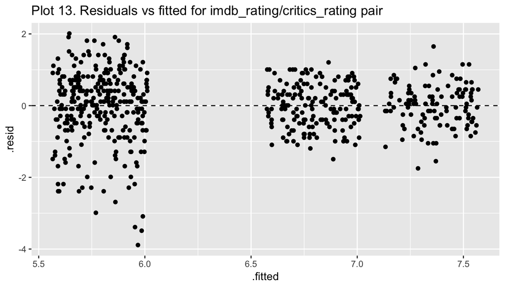

```r
m_obs4 <- lm(imdb_rating ~ critics_rating, data = ff)

ggplot(data = m_obs4, aes(x = .fitted, y = .resid)) +
  geom_jitter() +
  geom_hline(yintercept = 0, linetype = "dashed") +
  labs(title = "Plot 13. Residuals vs fitted for imdb_rating/critics_rating pair", xlab = "Fitted values", ylab = "Residuals")
```

The funnels we see is a perfect illustration of non-constant variability described earlier. Thus **we shouldn’t be using RT scores in predicting IMDb rating using multiple linear regression**.

The **full model** should then look like this:

```r
imdb_full <- lm(data = na.omit(ff), imdb_rating ~ genre + runtime + mpaa_rating + thtr_rel_year + thtr_rel_month + dvd_rel_year + dvd_rel_month + imdb_num_votes + best_pic_nom + best_pic_win + best_actor_win + best_actress_win + best_dir_win + top200_box)

summary(imdb_full)
```

```
##
## Call:
## lm(formula = imdb_rating ~ genre + runtime + mpaa_rating + thtr_rel_year +
##     thtr_rel_month + dvd_rel_year + dvd_rel_month + imdb_num_votes +
##     best_pic_nom + best_pic_win + best_actor_win + best_actress_win +
##     best_dir_win + top200_box, data = na.omit(ff))
##
## Residuals:
##     Min      1Q  Median      3Q     Max
## -3.8565 -0.4003  0.0640  0.5651  2.0824
##
## Coefficients:
##                                  Estimate Std. Error t value Pr(>|t|)
## (Intercept)                     4.866e+01  1.699e+01   2.864 0.004338 **
## genreAnimation                 -2.337e-01  3.524e-01  -0.663 0.507473
## genreArt House & International  9.544e-01  2.798e-01   3.411 0.000695 ***
## genreComedy                    -2.018e-02  1.449e-01  -0.139 0.889327
## genreDocumentary                1.040e+00  5.062e-01   2.054 0.040464 *
## genreDrama                      6.864e-01  1.245e-01   5.514 5.42e-08 ***
## genreHorror                    -9.576e-02  2.174e-01  -0.441 0.659747
## genreMusical & Performing Arts  1.185e+00  3.195e-01   3.710 0.000228 ***
## genreMystery & Suspense         4.349e-01  1.623e-01   2.680 0.007586 **
## genreOther                      4.487e-01  2.490e-01   1.802 0.072083 .
## genreScience Fiction & Fantasy -9.615e-02  3.174e-01  -0.303 0.762058
## runtime                         5.222e-03  2.616e-03   1.996 0.046437 *
## mpaa_ratingNC-17               -2.137e-01  8.832e-01  -0.242 0.808876
## mpaa_ratingPG                  -6.010e-01  2.597e-01  -2.315 0.021002 *
## mpaa_ratingPG-13               -8.153e-01  2.704e-01  -3.015 0.002693 **
## mpaa_ratingR                   -5.300e-01  2.624e-01  -2.020 0.043913 *
## mpaa_ratingUnrated              1.445e-01  3.546e-01   0.407 0.683912
## thtr_rel_year                  -1.130e-02  4.814e-03  -2.348 0.019255 *
## thtr_rel_month                  6.351e-03  1.069e-02   0.594 0.552615
## dvd_rel_year                   -1.025e-02  1.051e-02  -0.975 0.329956
## dvd_rel_month                   1.915e-02  1.070e-02   1.789 0.074139 .
## imdb_num_votes                  3.604e-06  3.732e-07   9.657  < 2e-16 ***
## best_pic_nomyes                 5.105e-01  2.221e-01   2.299 0.021898 *
## best_pic_winyes                -6.372e-01  3.915e-01  -1.628 0.104162
## best_actor_winyes               2.040e-03  1.041e-01   0.020 0.984374
## best_actress_winyes            -7.711e-03  1.140e-01  -0.068 0.946117
## best_dir_winyes                 2.640e-01  1.462e-01   1.806 0.071517 .
## top200_boxyes                  -9.188e-02  2.375e-01  -0.387 0.698942
## ---
## Signif. codes:  0 '***' 0.001 '**' 0.01 '*' 0.05 '.' 0.1 ' ' 1
##
## Residual standard error: 0.8398 on 545 degrees of freedom
## Multiple R-squared:  0.3925, Adjusted R-squared:  0.3624
## F-statistic: 13.04 on 27 and 545 DF,  p-value: < 2.2e-16
```

We’ll be using a **forward selection** technique here. The forward selection model starts with an empty model. Then, we add variables one-at-a-time until we cannot find any variables that improve the model (as measured by adjusted R<sup>2</sup>).

```r
# Forward selection based on adjusted r squared

# Create a subset of data that only includes variables we're interested in

ff_imdb <- subset(na.omit(ff), select = c("imdb_rating", "genre", "runtime", "mpaa_rating", "thtr_rel_year", "thtr_rel_month", "dvd_rel_year", "dvd_rel_month", "imdb_num_votes", "best_pic_nom", "best_pic_win", "best_actor_win", "best_actress_win", "best_dir_win", "top200_box"))

bestformula <- "imdb_rating ~" #starting point

result <- 0
bestresult <- 0
cycle = 2 #start with 2nd column of a data frame

while (cycle < ncol(ff_imdb)) {
  i = 2 #start with 2nd column of a data frame
  while (i <= ncol(ff_imdb)) {
    midformula = paste(as.character(bestformula), colnames(ff_imdb)[i], sep = " + ")
    midmodel = lm(as.formula(midformula), data = ff_imdb)
    midres = summary(midmodel)$adj.r.squared

    if (midres > result) {
      result = midres
      resformula = midformula
      resmodel = midmodel
    }
    i = i + 1
  }

  if (result > bestresult) {
    bestformula = resformula
    cycle = cycle + 1
  } else {
    break
  }
}

best_imdb_fwd_model = lm(bestformula, data = ff_imdb)
summary(best_imdb_fwd_model)
```

```
##
## Call:
## lm(formula = bestformula, data = ff_imdb)
##
## Residuals:
##     Min      1Q  Median      3Q     Max
## -3.9064 -0.4181  0.0616  0.5641  2.1156
##
## Coefficients:
##                                  Estimate Std. Error t value Pr(>|t|)
## (Intercept)                     3.338e+01  7.557e+00   4.417 1.20e-05 ***
## imdb_num_votes                  3.558e-06  3.589e-07   9.916  < 2e-16 ***
## genreAnimation                 -2.235e-01  3.491e-01  -0.640 0.522268
## genreArt House & International  9.436e-01  2.778e-01   3.396 0.000733 ***
## genreComedy                    -1.274e-02  1.433e-01  -0.089 0.929194
## genreDocumentary                1.028e+00  5.044e-01   2.038 0.042005 *
## genreDrama                      6.814e-01  1.226e-01   5.559 4.23e-08 ***
## genreHorror                    -1.085e-01  2.156e-01  -0.503 0.615221
## genreMusical & Performing Arts  1.194e+00  3.181e-01   3.754 0.000193 ***
## genreMystery & Suspense         4.210e-01  1.589e-01   2.650 0.008277 **
## genreOther                      4.267e-01  2.466e-01   1.731 0.084095 .
## genreScience Fiction & Fantasy -1.146e-01  3.159e-01  -0.363 0.716907
## thtr_rel_year                  -1.393e-02  3.780e-03  -3.687 0.000250 ***
## mpaa_ratingNC-17               -1.351e-01  8.774e-01  -0.154 0.877677
## mpaa_ratingPG                  -5.943e-01  2.576e-01  -2.307 0.021410 *
## mpaa_ratingPG-13               -8.015e-01  2.678e-01  -2.993 0.002887 **
## mpaa_ratingR                   -5.053e-01  2.591e-01  -1.950 0.051665 .
## mpaa_ratingUnrated              1.363e-01  3.515e-01   0.388 0.698307
## runtime                         5.549e-03  2.466e-03   2.250 0.024863 *
## best_pic_nomyes                 5.246e-01  2.166e-01   2.422 0.015748 *
## dvd_rel_month                   1.829e-02  1.048e-02   1.746 0.081419 .
## best_dir_winyes                 2.696e-01  1.456e-01   1.852 0.064582 .
## best_pic_winyes                -6.654e-01  3.875e-01  -1.717 0.086489 .
## ---
## Signif. codes:  0 '***' 0.001 '**' 0.01 '*' 0.05 '.' 0.1 ' ' 1
##
## Residual standard error: 0.8371 on 550 degrees of freedom
## Multiple R-squared:  0.3909, Adjusted R-squared:  0.3665
## F-statistic: 16.04 on 22 and 550 DF,  p-value: < 2.2e-16
```

As a result, we come up with a model **imdb_rating ~ + imdb_num_votes + genre + thtr_rel_year + mpaa_rating + runtime + best_pic_nom + dvd_rel_month + best_dir_win + best_pic_win** with adjusted R<sup>2</sup> of **0.3665422** which is slightly higher than that of a full model (0.3624447). However, we can see that some of the variables have a p-value above the significance level of 5%. The order of certain variable in the formula tells us about its impact on the adjusted R<sup>2</sup> (the earlier in the formula, the greater the impact).

Let’s try a backward elimination technique and compare the resulting model with the model above. **Backward elimination** starts with the model that includes all potential predictor variables. Variables are eliminated one-at-a-time from the model until we cannot improve the adjusted R<sup>2</sup>. At each step we eliminate the variable that leads to the largest improvement in adjusted R<sup>2</sup>.

```r
#predictors <- model.matrix(imdb_full)[,-1] # move the names of the predictors to matrix
bwrd_bestpredictors = c("genre", "runtime", "mpaa_rating", "thtr_rel_year", "thtr_rel_month", "dvd_rel_year", "dvd_rel_month", "imdb_num_votes", "best_pic_nom", "best_pic_win", "best_actor_win", "best_actress_win", "best_dir_win", "top200_box")
midpredictors = bwrd_bestpredictors
bwrd_result <- summary(imdb_full)$adj.r.squared
test_predictors = c()

while (length(bwrd_bestpredictors) > 0) {
  i = 1
  adjr2 = c()
  while (i <= length(midpredictors)) {
    test_predictors = midpredictors[-(i)]
    midformula = as.formula(paste("imdb_rating ~ ", paste(test_predictors, collapse = " + "), sep = ""))
    midmodel = lm(midformula, data = ff_imdb)
    midres = summary(midmodel)$adj.r.squared
    adjr2 = append(adjr2, midres, after = length(adjr2))
    i = i + 1
    }

  if (max(adjr2) > bwrd_result) {
    midpredictors = midpredictors[-(which.max(adjr2))]
    bwrd_bestpredictors = midpredictors
    bwrd_result = max(adjr2)
  } else {break}
}

bwrd_bestformula = as.formula(paste("imdb_rating ~ ", paste(bwrd_bestpredictors, collapse = " + "), sep = ""))
imdb_bwrd_best_model = lm(bwrd_bestformula, data = ff_imdb)
summary(imdb_bwrd_best_model)
```

```
##
## Call:
## lm(formula = bwrd_bestformula, data = ff_imdb)
##
## Residuals:
##     Min      1Q  Median      3Q     Max
## -3.9064 -0.4181  0.0616  0.5641  2.1156
##
## Coefficients:
##                                  Estimate Std. Error t value Pr(>|t|)
## (Intercept)                     3.338e+01  7.557e+00   4.417 1.20e-05 ***
## genreAnimation                 -2.235e-01  3.491e-01  -0.640 0.522268
## genreArt House & International  9.436e-01  2.778e-01   3.396 0.000733 ***
## genreComedy                    -1.274e-02  1.433e-01  -0.089 0.929194
## genreDocumentary                1.028e+00  5.044e-01   2.038 0.042005 *
## genreDrama                      6.814e-01  1.226e-01   5.559 4.23e-08 ***
## genreHorror                    -1.085e-01  2.156e-01  -0.503 0.615221
## genreMusical & Performing Arts  1.194e+00  3.181e-01   3.754 0.000193 ***
## genreMystery & Suspense         4.210e-01  1.589e-01   2.650 0.008277 **
## genreOther                      4.267e-01  2.466e-01   1.731 0.084095 .
## genreScience Fiction & Fantasy -1.146e-01  3.159e-01  -0.363 0.716907
## runtime                         5.549e-03  2.466e-03   2.250 0.024863 *
## mpaa_ratingNC-17               -1.351e-01  8.774e-01  -0.154 0.877677
## mpaa_ratingPG                  -5.943e-01  2.576e-01  -2.307 0.021410 *
## mpaa_ratingPG-13               -8.015e-01  2.678e-01  -2.993 0.002887 **
## mpaa_ratingR                   -5.053e-01  2.591e-01  -1.950 0.051665 .
## mpaa_ratingUnrated              1.363e-01  3.515e-01   0.388 0.698307
## thtr_rel_year                  -1.393e-02  3.780e-03  -3.687 0.000250 ***
## dvd_rel_month                   1.829e-02  1.048e-02   1.746 0.081419 .
## imdb_num_votes                  3.558e-06  3.589e-07   9.916  < 2e-16 ***
## best_pic_nomyes                 5.246e-01  2.166e-01   2.422 0.015748 *
## best_pic_winyes                -6.654e-01  3.875e-01  -1.717 0.086489 .
## best_dir_winyes                 2.696e-01  1.456e-01   1.852 0.064582 .
## ---
## Signif. codes:  0 '***' 0.001 '**' 0.01 '*' 0.05 '.' 0.1 ' ' 1
##
## Residual standard error: 0.8371 on 550 degrees of freedom
## Multiple R-squared:  0.3909, Adjusted R-squared:  0.3665
## F-statistic: 16.04 on 22 and 550 DF,  p-value: < 2.2e-16
```

We came up to **the same model** using backward elimination technique. We should run a diagnostic for the following predictors included in a model:

**genre, runtime, mpaa_rating, thtr_rel_year, dvd_rel_month, imdb_num_votes, best_pic_nom, best_pic_win, best_dir_win**

```r
library(olsrr)
imdb_backward_p <- ols_step_backward_p(imdb_full, details = F, p = 0.05)
```

```
## Backward Elimination Method
## ---------------------------
##
## Candidate Terms:
##
## 1 . genre
## 2 . runtime
## 3 . mpaa_rating
## 4 . thtr_rel_year
## 5 . thtr_rel_month
## 6 . dvd_rel_year
## 7 . dvd_rel_month
## 8 . imdb_num_votes
## 9 . best_pic_nom
## 10 . best_pic_win
## 11 . best_actor_win
## 12 . best_actress_win
## 13 . best_dir_win
## 14 . top200_box
##
## We are eliminating variables based on p value...
##
## Variables Removed:
##
## - best_actor_win
## - best_actress_win
## - top200_box
## - thtr_rel_month
## - dvd_rel_year
## - best_pic_win
## - best_dir_win
## - dvd_rel_month
## - best_pic_nom
##
## No more variables satisfy the condition of p value = 0.05
##
##
## Final Model Output
## ------------------
##
```

[output cut: 30 more lines]

```
##                     genreDrama     0.687         0.123        0.327     5.601    0.000     0.446     0.929
##                    genreHorror    -0.095         0.217       -0.017    -0.437    0.662    -0.521     0.331
## genreMusical & Performing Arts     1.170         0.320        0.131     3.655    0.000     0.541     1.798
##        genreMystery & Suspense     0.419         0.160        0.118     2.622    0.009     0.105     0.732
##                     genreOther     0.463         0.247        0.070     1.876    0.061    -0.022     0.948
## genreScience Fiction & Fantasy    -0.077         0.318       -0.009    -0.242    0.809    -0.701     0.547
##                        runtime     0.007         0.002        0.115     2.847    0.005     0.002     0.012
##               mpaa_ratingNC-17    -0.030         0.882       -0.001    -0.034    0.973    -1.762     1.702
##                  mpaa_ratingPG    -0.566         0.259       -0.208    -2.185    0.029    -1.075    -0.057
##               mpaa_ratingPG-13    -0.781         0.270       -0.310    -2.897    0.004    -1.310    -0.251
##                   mpaa_ratingR    -0.481         0.261       -0.228    -1.844    0.066    -0.993     0.031
##             mpaa_ratingUnrated     0.146         0.354        0.023     0.413    0.679    -0.549     0.841
##                  thtr_rel_year    -0.014         0.004       -0.149    -3.822    0.000    -0.022    -0.007
##                 imdb_num_votes     0.000         0.000        0.414    10.790    0.000     0.000     0.000
## -----------------------------------------------------------------------------------------------------------
```

## Part 6: Conclusion